# Лабораторная работа 5. Основы анализа данных NumPy и Matplotlib.

# Часть 1. NumPy

При решении научных задач с помощью численных методов зачастую приходится иметь дело с большими массивами данных в виде массивов и матриц. Стандартные средства Python (например, использование списков для хранения данных и прямой перебор элементов с помощью циклов) плохо подходят для таких задач, так как будут работать крайне медленно, в отличие от программ на компилируемых языках (Fortran, С). Пакет NumPy (http://www.numpy.org/) — это основной пакет, исполь¬зуемый в научных вычислениях в Python. NumPy предназначен для эф¬фективной работы с многомерными массивами, в том числе для эффек¬тивного применения математических операций к массивам и матрицам и их модификации без прямого перечисления элементов массивов. Поми¬мо этого NumPy обладает и другими возможностями — линейная алгеб¬ра, удобный ввод/вывод в файлы, моделирование случайных величин, быстрое преобразование Фурье, объединение программ на Fortran и С и другое (подробнее см. оф. сайт), поэтому важно изучить возможно¬сти данной библиотеки как можно лучше.

1. Внимательно изучите следующий урок по NumPy: http://scipy.github.io/old-wiki/pages/Tentative_NumPy_Tutorial.
2. Изучите официальное руководство пользователя https://docs.scipy.org/doc/numpy/user/.
3. Внимательно изучите Reference Guide (полное описание всех функ¬ций) https://docs.scipy.org/doc/numpy/reference/, именно в нем перечислены все возможности NumPy, этой ссылкой придется регу¬лярно пользоваться.

Выполните следующие задания (их много, но каждое занимает одну или несколько строк) средствами NumPy (и без использования циклов!)

Импортируйте пакет numpy под именем nр

```python
import numpy as np
```

Импортируйте пакет numpy под именем пр

```python
import numpy as np
```

Создайте вектор из 10 элементов, заполненный 0, пятый эле-мент которого равен 1.

```python
import numpy as np
vector = np.zeros(10)
vector[4]=1
print(vector)
```

```
[0. 0. 0. 0. 1. 0. 0. 0. 0. 0.]
```

Создайте вектор из 10 элементов, заполненный 0, пятый эле-мент которого равен 1.

```python
import numpy as np
vector = np.zeros(10)
vector[4]=1
print(vector)
```

```
[0. 0. 0. 0. 1. 0. 0. 0. 0. 0.]
```

Создайте матрицу 3 на 3 со значениями от 0 до 8.

```python
import numpy as np
vector = np.arange(9).reshape(3,3)
print(vector)
```

```
[[0 1 2]
 [3 4 5]
 [6 7 8]]
```

Найдите индексы ненулевых элементов вектора [1,2,0,0,4,0].

```python
import numpy as np
nonz = np.nonzero([1,2,0,0,4,0])
print(nonz)
```

```
(array([0, 1, 4], dtype=int32),)
```

Объявите единичную матрицу размером 3 на 3.

```python
import numpy as np
matrix = np.eye(3)
print(matrix)
```

```
[[1. 0. 0.]
 [0. 1. 0.]
 [0. 0. 1.]]
```

Создайте массив 10x10x10 из случайных чисел.

```python
import numpy as np
array = np.random.random((10,10,10))
print(array)
```

[output not shown]

[output cut: 254 more lines]

[output not shown]

Создайте матрицу 8 на 8, заполненную 0 и 1 в шахматном порядке.

```python
import numpy as np
matrix = np.zeros((8,8), dtype=int)
matrix[0::2,::2] = 1
matrix[1::2,1::2] = 1
print(matrix)
```

```
[[1 0 1 0 1 0 1 0]
 [0 1 0 1 0 1 0 1]
 [1 0 1 0 1 0 1 0]
 [0 1 0 1 0 1 0 1]
 [1 0 1 0 1 0 1 0]
 [0 1 0 1 0 1 0 1]
 [1 0 1 0 1 0 1 0]
 [0 1 0 1 0 1 0 1]]
```

Найдите произведение матриц 5x3 на 3x2 (см. линейную ал-гебру) .

```python
import numpy as np
A=np.random.random((5,3))
B=np.random.random((3,2))
matrix = np.dot(A, B)
print(A,"\n","\n",B,"\n","\n",matrix)
```

```
[[0.97439324 0.70840529 0.4324003 ]
 [0.06565795 0.97244877 0.05300744]
 [0.39911804 0.20271727 0.97343776]
 [0.87033947 0.27194273 0.76414133]
 [0.08279542 0.18869396 0.93193191]]

 [[0.46335331 0.595597  ]
 [0.13748894 0.74996707]
 [0.34064865 0.79696965]]

 [[0.6961828  1.45623624]
 [0.18218069 0.81065556]
 [0.5444043  1.16554513]
 [0.70096751 1.33131712]
 [0.38176821 0.9335484 ]]
```

```python
import numpy as np
matrix = np.zeros((9,9), dtype=int)
A=np.arange(9)
B=matrix+np.repeat(A,9).reshape(9,9)
print(matrix,"\n","\n",A,"\n","\n",B)
```

```
[[0 0 0 0 0 0 0 0 0]
 [0 0 0 0 0 0 0 0 0]
 [0 0 0 0 0 0 0 0 0]
 [0 0 0 0 0 0 0 0 0]
 [0 0 0 0 0 0 0 0 0]
 [0 0 0 0 0 0 0 0 0]
 [0 0 0 0 0 0 0 0 0]
 [0 0 0 0 0 0 0 0 0]
 [0 0 0 0 0 0 0 0 0]]

 [0 1 2 3 4 5 6 7 8]

 [[0 0 0 0 0 0 0 0 0]
 [1 1 1 1 1 1 1 1 1]
 [2 2 2 2 2 2 2 2 2]
 [3 3 3 3 3 3 3 3 3]
 [4 4 4 4 4 4 4 4 4]
 [5 5 5 5 5 5 5 5 5]
 [6 6 6 6 6 6 6 6 6]
 [7 7 7 7 7 7 7 7 7]
 [8 8 8 8 8 8 8 8 8]]
```

## Часть 2. Matplotlib

Matplotlib (http://matplotlib.org/index.html) — это библиотека для создания графиков в Python. Matplotlib позволяет строить графики любой сложности типографского качества, которые можно вставить в статью. Подробнее о возможностях см. http://matplotlib.org/users/ intro.html. Matplotlib — большой и сложный инструмент, но на прак¬тике в научных вычислениях часто пользуются частью библиотеки matplotlib .pyplot, которая имитирует построение графиков в стиле MATLAB. В качестве до¬статочно полного введения можно прочитать http://matplotlib.org/users/index.html.

На практике бывает очень трудно помнить все возможности Matplotlib, поэтому часто используют галереи готовых примеров, а потом модифи-цируют их под свои нужды. Примеры таких подборок можно найти по следующим ссылкам: • http://matplotlib.org/gallery.html • http://matplotlib.org/examples/index.html • http://wiki.scipy.org/Cookbook/Matplotlib/

Еще материалы.

1. Введение http://matplotlib.org/users/pyplot_tutorial.html
2. Введение 2 http://www.loria.fr/~rougier/teaching/matplotlib/. Изучите, как создавать графики разных типов http://www.loria. fr/~rougier/teaching/matplotlib/#other-types-of-plots.
3. Использование текста в подписях и т.д. http://matplotlib.org/ users/text_intro.html.
4. Использование математического текста http: //matplotlib. org/users/ mathtext.html.
5. Создание легенды http://matplotlib.org/users/legend_guide.html.
6. Интерактивное использование Matplotlib http: //matplotlib. org/ users/shell .html (этот пример можно использовать не только в командной строке, но и в коде для наблюдения за изменением гра¬фиков в ходе выполнения программы).

Постройте поточечный график функции. Сгенерируйте два массива для этого. Один со значениями по возрастанию (для X), второй со случайными значениями (для Y).

```
[0 1 2 3 4 5 6 7 8] [0.12635061 0.916028   0.10512855 0.18143959 0.82946304 0.1630009
 0.20636835 0.49250336 0.62085582]
```

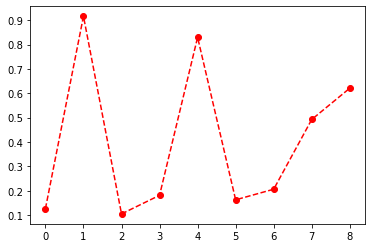

```python
import math
import matplotlib.pyplot as plt
import numpy as np

A=np.arange(9)
B=np.random.random(9)
print(A,B)
print(plt.plot(A, B, 'r--o'))
```

Выберите тригонометрическую функцию $T(x)$, выберите полином $P(x)$. Постройте график функции $T(x)P(x)$.

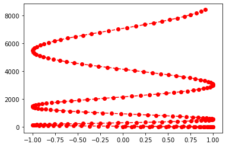

```python
x=x = np.linspace(0, 20, 200)
T=np.sin(x)
P=1+x*x+x*x*x
print(plt.plot(T, P, 'r--o'))
```

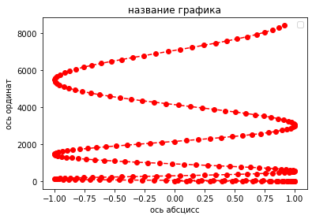

```python
x=x = np.linspace(0, 20, 200)
T=np.sin(x)
P=1+x*x+x*x*x
plt.xlabel('ось абсцисс')
plt.ylabel('ось ординат')
plt.title('название графика')
plt.legend('вставка легенды')
print(plt.plot(T, P, 'r--o'))
```

Измените цвет графика на Ваш любимый.

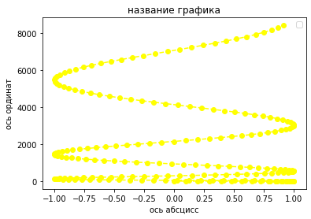

```python
x=x = np.linspace(0, 20, 200)
T=np.sin(x)
P=1+x*x+x*x*x
plt.xlabel('ось абсцисс')
plt.ylabel('ось ординат')
plt.title('название графика')
plt.legend(['вставка легенды'])
print(plt.plot(T, P, 'r--o',color="yellow"))
```

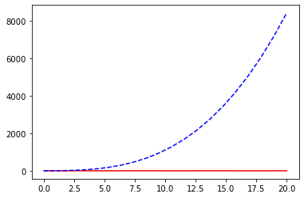

```python
x=x = np.linspace(0, 20, 20)
T=np.sin(x)
P=1+x*x+x*x*x
plt.plot(x,T,'r')
plt.plot(x,P,'r--', color="blue")
```

Постройте теже графики, только для первого добавьте маркеры из красных треугольников, для второго синие круглые маркеры.

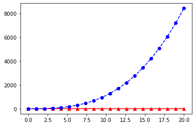

```python
x=x = np.linspace(0, 20, 20)
T=np.sin(x)
P=1+x*x+x*x*x
fig, plt1 = plt.subplots()
plt.plot(x,T,'r-^')
plt.plot(x,P,'r--o', color="blue")
fig.savefig('save')
```

# Часть 3. OpenCV

Прочитайте картинку используя opencv

[figure not shown]

```python
import cv2
import matplotlib.pyplot as plt
img = cv2.imread('082cf32e5a8846ae89628b2780595cf1.jpg')
plt.imshow(img)
```

[figure not shown]

```python
import cv2
import matplotlib.pyplot as plt
img = cv2.imread('082cf32e5a8846ae89628b2780595cf1.jpg')
plt.imshow(img[:,:,0])
```

Измените размер на 300x300

```python
img = cv2.resize(img, (300, 300))
```

Разбейте ее на 2 картинки. Сохраните.

```python
(h, w) = img.shape[:2]
left = img[:h, :w//2]
right = img[:h, w//2:]
cv2.imwrite('left.png', left)
cv2.imwrite('right.png', right)
```

```
True
```

Прочитайте 2 картинки и склейте.

[figure not shown]

```python
import numpy as np
img1 = cv2.imread('left.png',1)
img2 = cv2.imread('right.png',1)
vis = np.concatenate((img1, img2), axis=1)
plt.imshow(vis)
```